# Ch19Practice

Justine

2021/7/3

# Home

### 是非題

1.(O)R語言內建了許多的繪圖工具函數以供參考使用，我們可以先使用demo(graphics)或者demo(image)兩個指令來參考R所提供的繪圖示範  
2.(O)低階繪圖(Low-level Plotting Functions)是用在一個已經繪製好的圖形上加上其他的圖形元素，例如加上說明文字、直線或點等等  
3.(X)低階繪圖(Low-level Plotting Functions)是用在建立一個新的圖形，常用的各種統計繪圖，基本上都是屬於低階繪圖  
4.(X)互動式繪圖(Interactive Graphics Functions)：允許使用者以互動的方式使用其他的設備，例如滑鼠， 在一個已經存在的圖形上加入繪圖相關資訊，例如：points()以及text()兩函數都是屬於互動式繪圖  
5.(O)我們可以使用dev.new()函數來打開一個新的繪圖設備；而使用dev.off(x)來關閉指定的繪圖設備  
6.(X)我們可以使用graphics.off()來關閉某一個指定的繪圖設備  
7.(X)mfrow參數設置不需要透過par()來設置，是可以作為高階或者低階繪圖中函數參數的設置使用  
8.(X)我們可以使用square()低階繪圖函數來繪製四邊形  
9.(O)abline()低階繪圖函數可以用來繪製水平或者垂直線條於指定座標處  
10.(O)curve()以及coplot()兩函數均是屬於高階繪圖函數

### 選擇題

1.(D)以下哪個函數可以用來來關閉某一個指定的繪圖設備?  
(A)dev.quit() (B)dev.down()  
(C)graphics.off() (D)dev.off()  
2.(A)以下哪個函數是屬於互動式繪圖(Interactive Graphics Functions)?  
(A)identify() (B)text() (C)plot() (D)pairs()  
3.(B)以下哪個函數是屬於低階繪圖(Low-level Plotting Functions)?  
(A)identify() (B)text() (C)plot() (D)pairs()  
4.(A)以下哪個函數不屬於高階繪圖(High-level Plotting Functions)?  
(A)identify() (B)hist() (C)plot() (D)pairs() 5.(A)以下的繪圖結果是由哪一組指令所獲得的?  
(A)

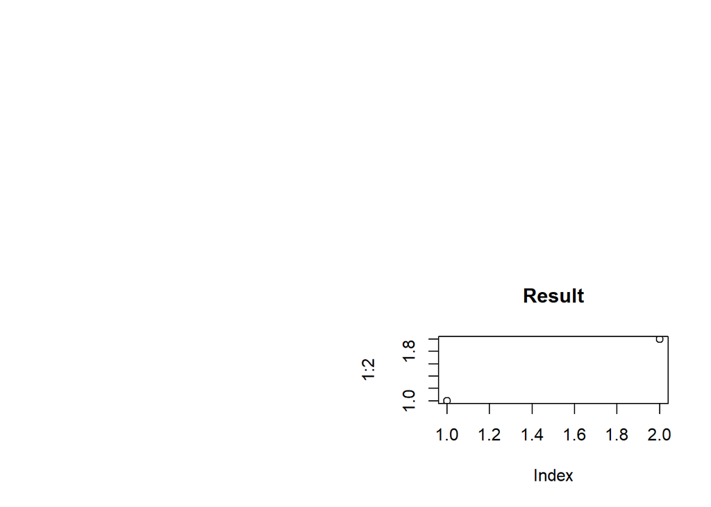

```r
par(fig=c(0.5,1,0,0.5))
plot(1:2,main="Result")
```

(B)

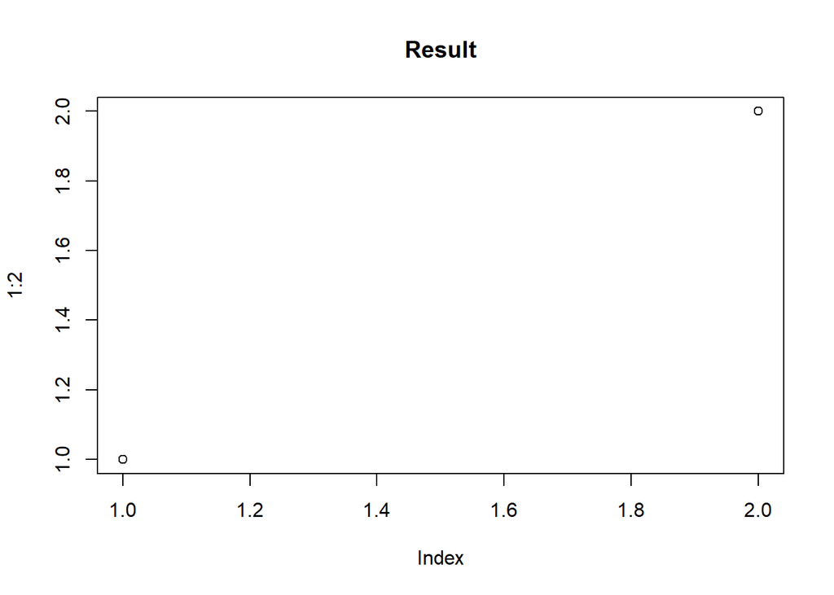

```r
plot(1:2,main="Result")
```

(C)

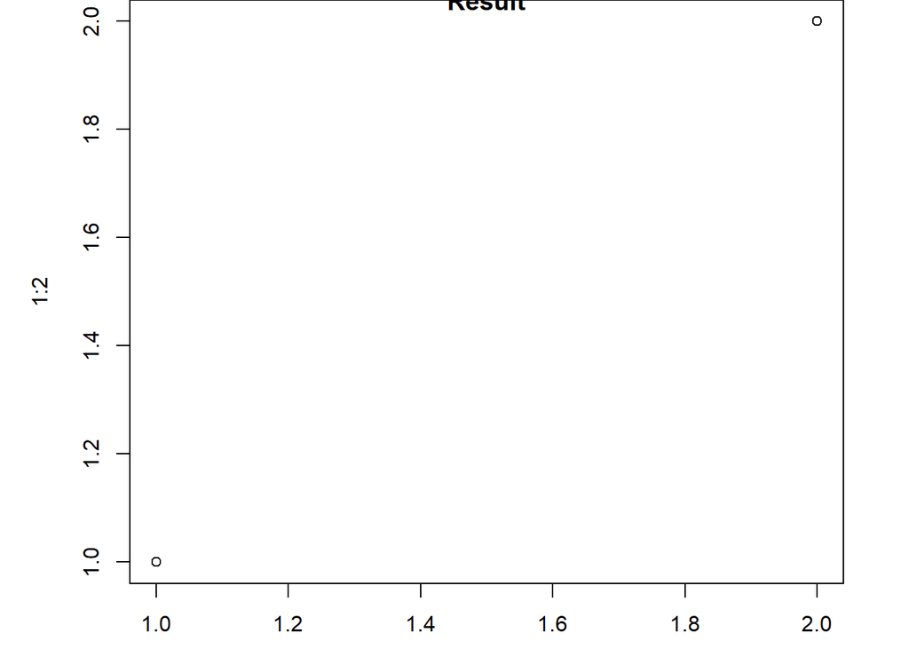

```r
par(mai=c(0.5,1,0,0.5))
plot(1:2,main="Result")
```

(D)

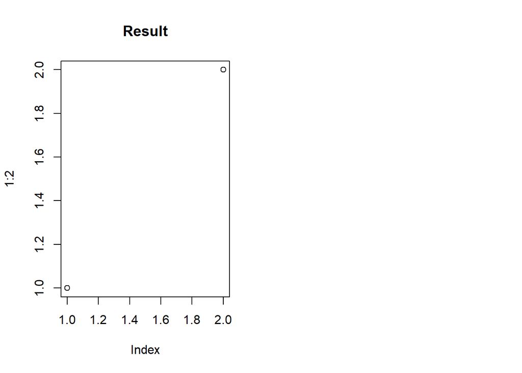

```r
par(mfrow=c(1,2))
plot(1:2,main="Result")
```

6.(A)如果我們要以下列R的群組程式產生如下兩個繪圖的佈局，矩陣x應該事先被定義為何?  
> nf <- layout(x,widths=c(1,1),+heights = c(1,1),respect=TRUE) > layout.show(nf)

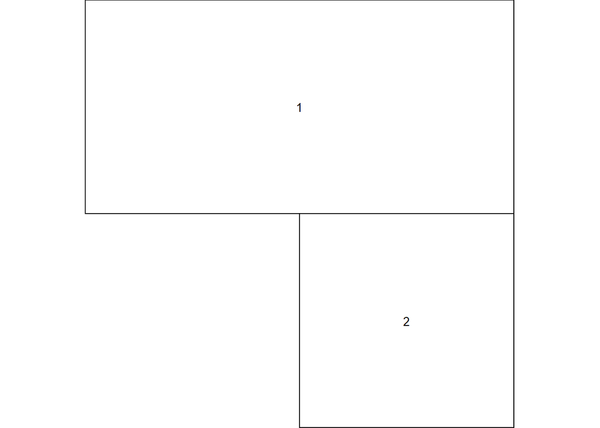

```r
x <- matrix(c(1,1,0,2),2,2,byrow = TRUE)
nf <- layout(x,widths = c(1,1),heights = c(1,1),respect=TRUE)
layout.show(nf)
```

(B)

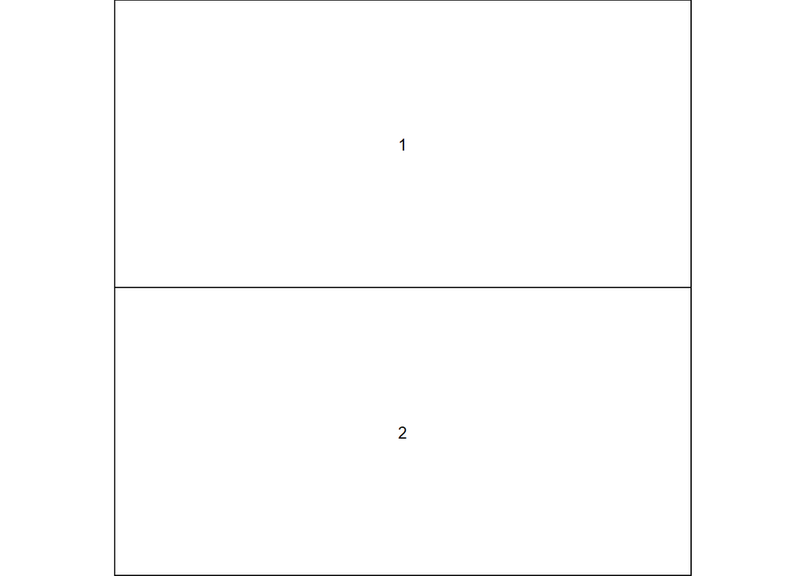

```r
x <- matrix(c(1,1,2,2),2,2,byrow = TRUE)
nf <- layout(x,widths = c(1,1),heights = c(1,1),respect=TRUE)
layout.show(nf)
```

(C)

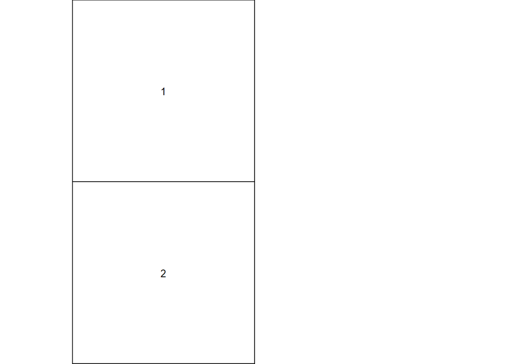

```r
x <- matrix(c(1,0,2,0),2,2,byrow = TRUE)
nf <- layout(x,widths = c(1,1),heights = c(1,1),respect=TRUE)
layout.show(nf)
```

(D)

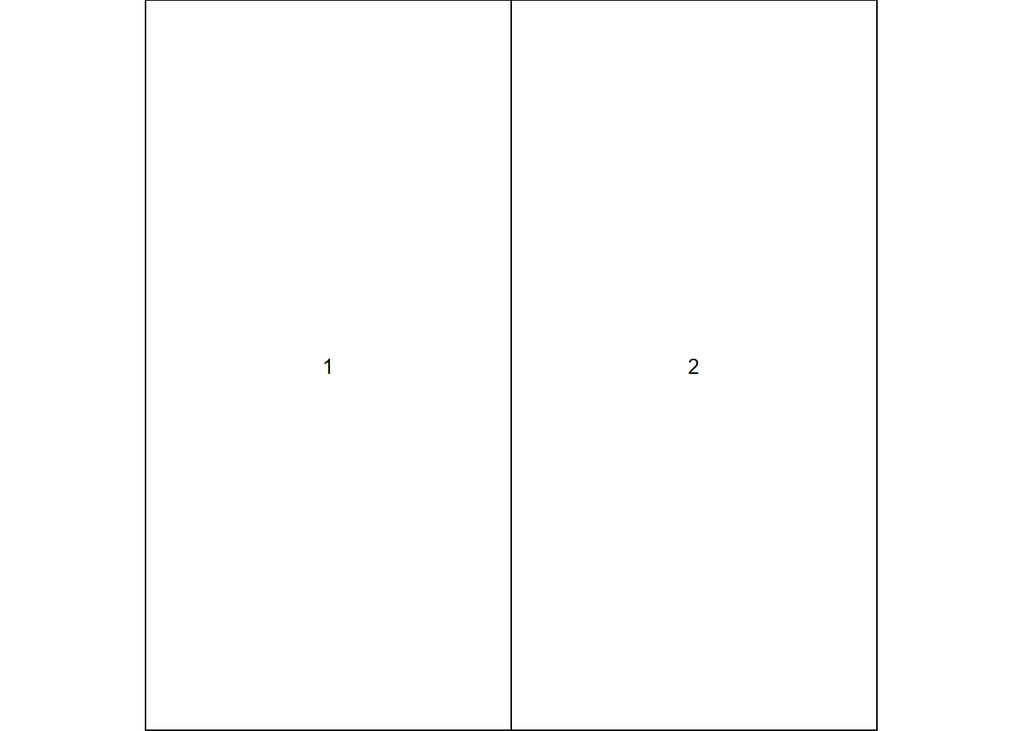

```r
x <- matrix(c(1,2,1,2),2,2,byrow = TRUE)
nf <- layout(x,widths = c(1,1),heights = c(1,1),respect=TRUE)
layout.show(nf)
```

7.(A)如果我們要使用plot()函數產生如下垂直軸經過log()函數轉換的繪圖，正確R指令會是哪一個?  
(A)

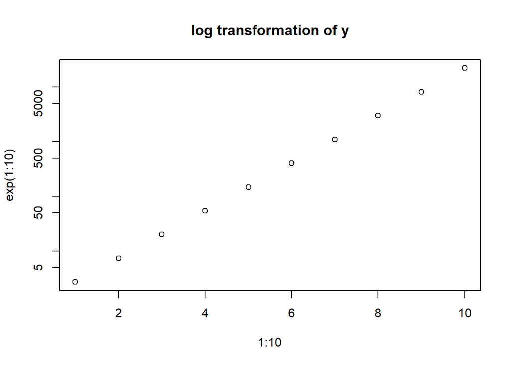

```r
plot(x=1:10,y=exp(1:10),log="y",main="log transformation of y")
```

(B)

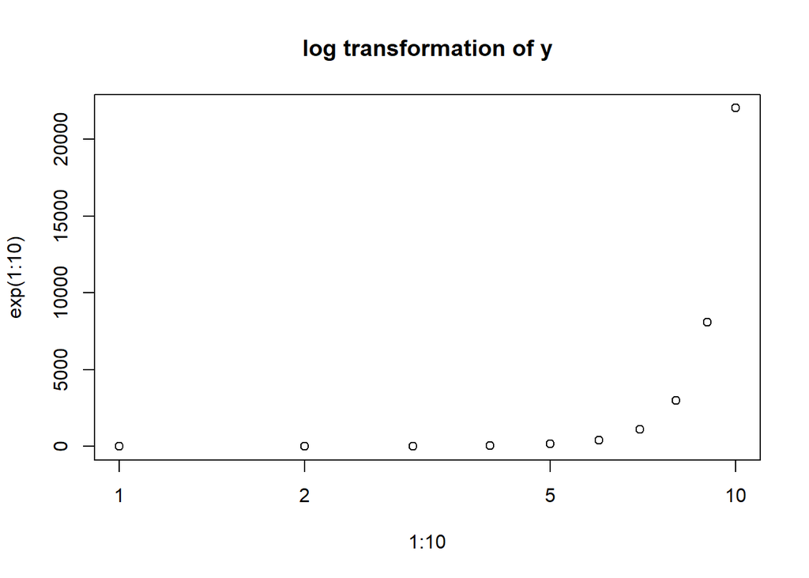

```r
plot(x=1:10,y=exp(1:10),log="x",main="log transformation of y")
```

(C)

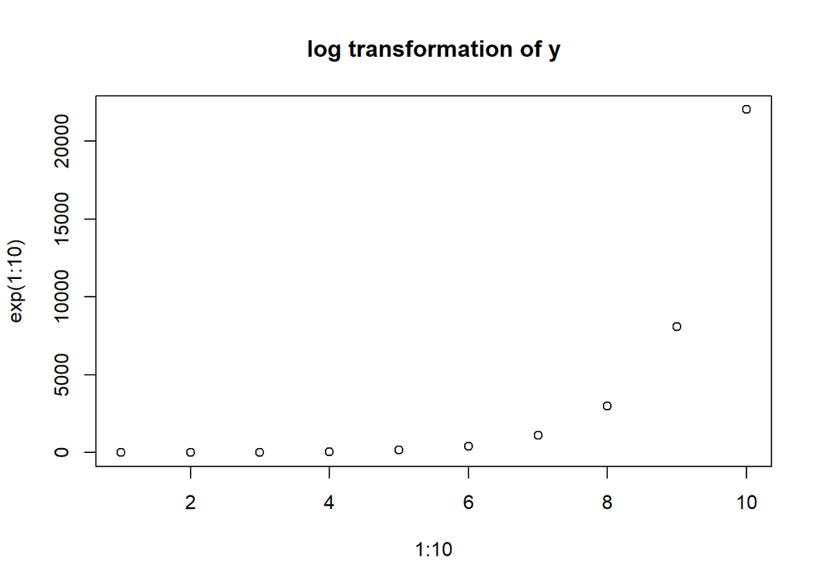

```r
plot(x=1:10,y=exp(1:10),main="log transformation of y")
```

(D)

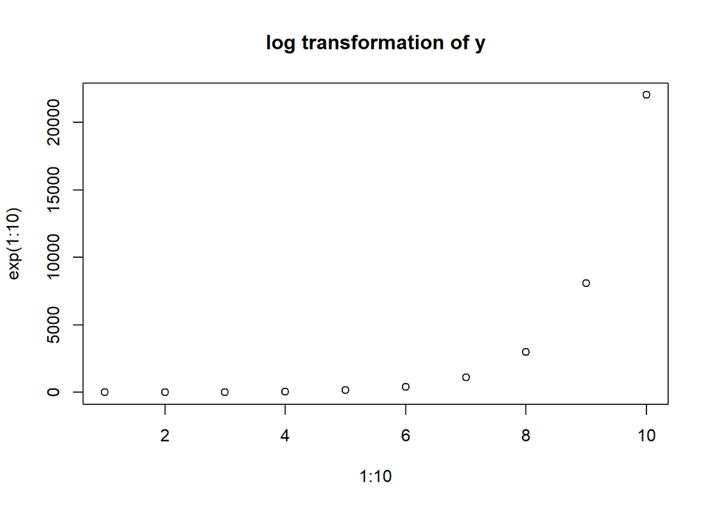

```r
plot(x=1:10,y=exp(1:10),ylog=TRUE,main="log transformation of y")
```

8.(D)以下哪個函數不是R繪製3D圖形函數?  
(A)persp() (B)contour() (C)image() (D)3Dplot()  
9.(C)低階繪圖arrow()函數的參數code設定為何者時可以在兩個端點都繪製箭頭?  
(A)1 (B)2 (C)3 (D)4  
10.(A)低階繪圖polygon()函數使用何種參數來設定每ㄧ英吋內陰影的線條數?  
(A)density (B)lty (C)col (D)lines  
11.(D)以下哪個函數可以用來產生Normal Distribution的隨機數?  
(A)dnorm() (B)pnrom() (C)qnorm() (D)rnorm()  
13.(D)何組R指令會產生以下圖型?  
(A)

```r
x=1:10
y=c(2,7,3,5,9,8,7,6,1,7)
plot(x,y)
```

```r
line(1:10)
```

```
##
## Call:
## line(1:10)
##
## Coefficients:
## [1]  0  1
```

```r
x=1:10
y=c(2,7,3,5,9,8,7,6,1,7)
plot(x,y)
```

```r
line(x,y)
```

```
##
## Call:
## line(x, y)
##
## Coefficients:
## [1]  3.0833  0.4167
```

```r
x=1:10
y=c(2,7,3,5,9,8,7,6,1,7)
plot(x,y)
```

```r
#line(lm(y~x))
```

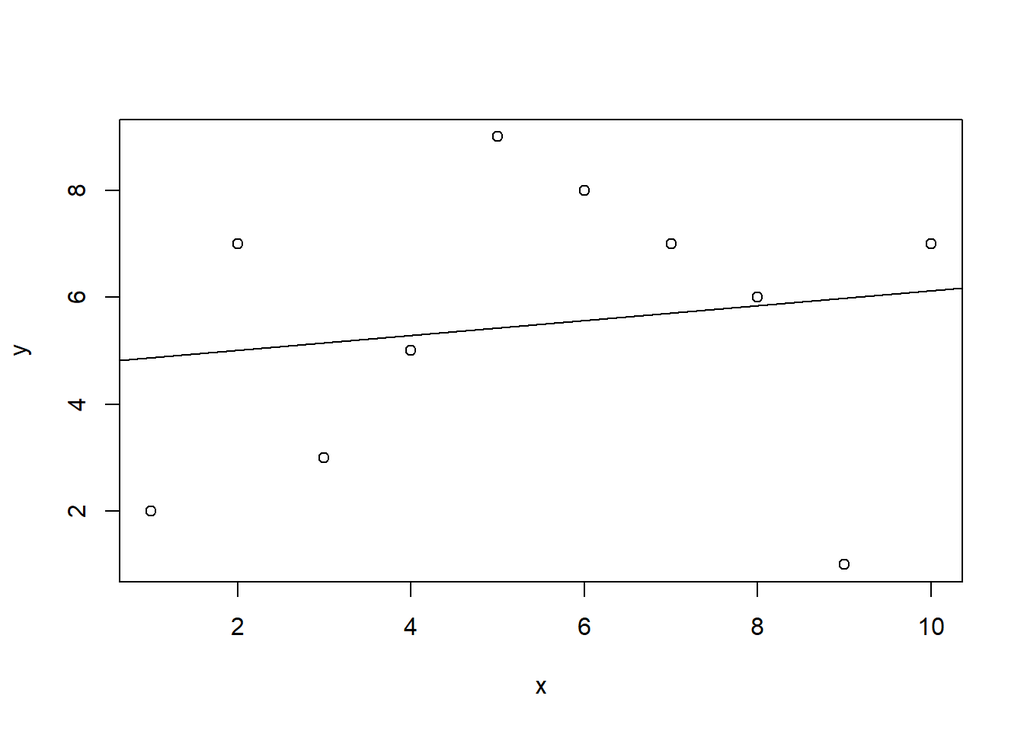

```r
x=1:10
y=c(2,7,3,5,9,8,7,6,1,7)
plot(x,y)
abline(lm(y~x))
```

14.(A)何組R指令會產生以下圖型?  
(A)

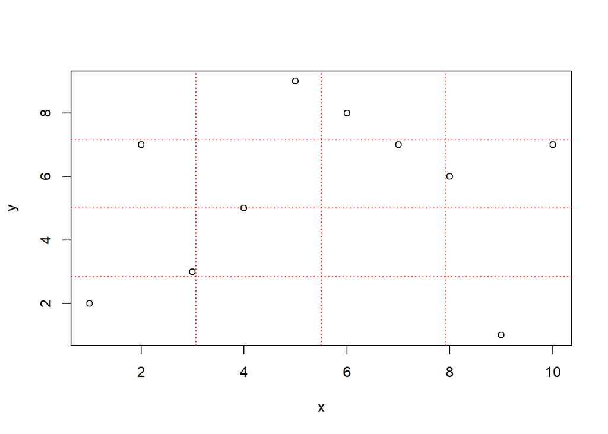

```r
x=1:10
y=c(2,7,3,5,9,8,7,6,1,7)
plot(x,y)
grid(nx=4,ny=4,col = "red")
```

(B)

```r
x=1:10
y=c(2,7,3,5,9,8,7,6,1,7)
plot(x,y)
```

```r
#lines(nx=4,ny=4,col = "red")
```

```r
x=1:10
y=c(2,7,3,5,9,8,7,6,1,7)
plot(x,y)
```

```r
#points(nx=4,ny=4,col = "red")
```

```r
x=1:10
y=c(2,7,3,5,9,8,7,6,1,7)
plot(x,y)
```

```r
#grids(nx=4,ny=4,col = "red")
```

15.(C)何組R指令會產生以下圖型?  
(A)

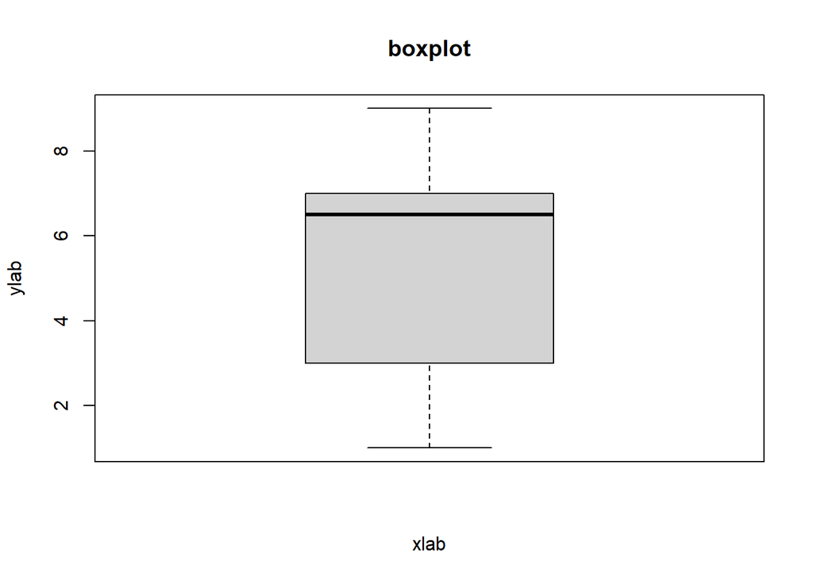

```r
boxplot(y)
title(main = "boxplot",xlab = "xlab",ylab = "ylab")
```

(B)

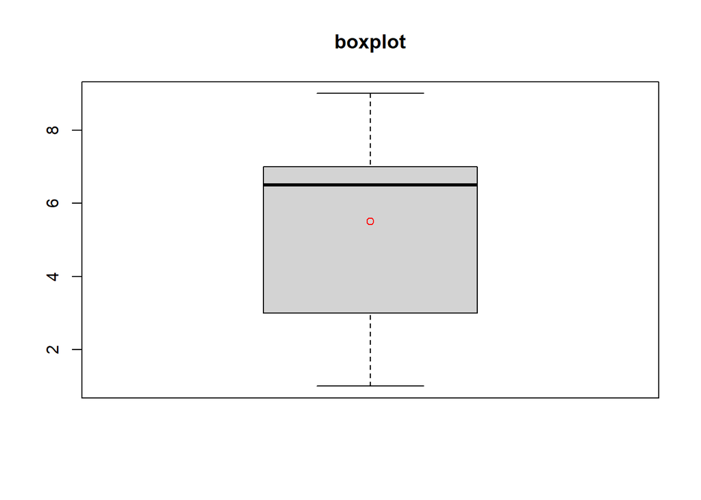

```r
boxplot(y)
title(main = "boxplot",x_lab = "xlab",y_lab = "ylab")
points(mean(y),col="red")
```

(C)

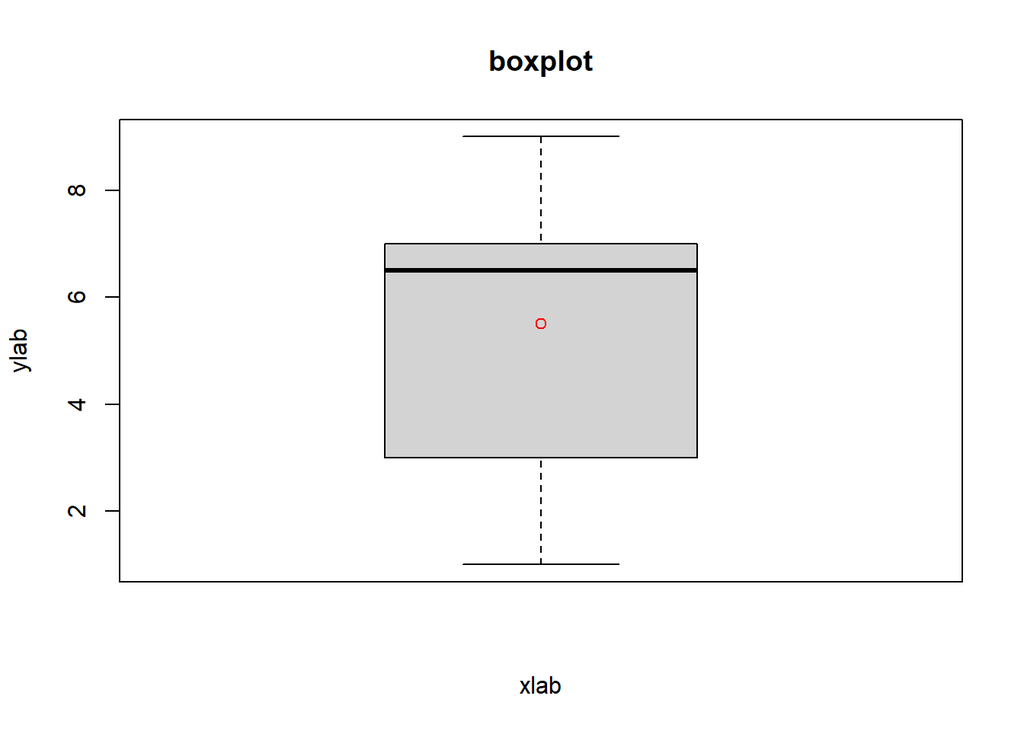

```r
boxplot(y)
title(main = "boxplot",xlab = "xlab",ylab = "ylab")
points(mean(y),col="red")
```

(D)

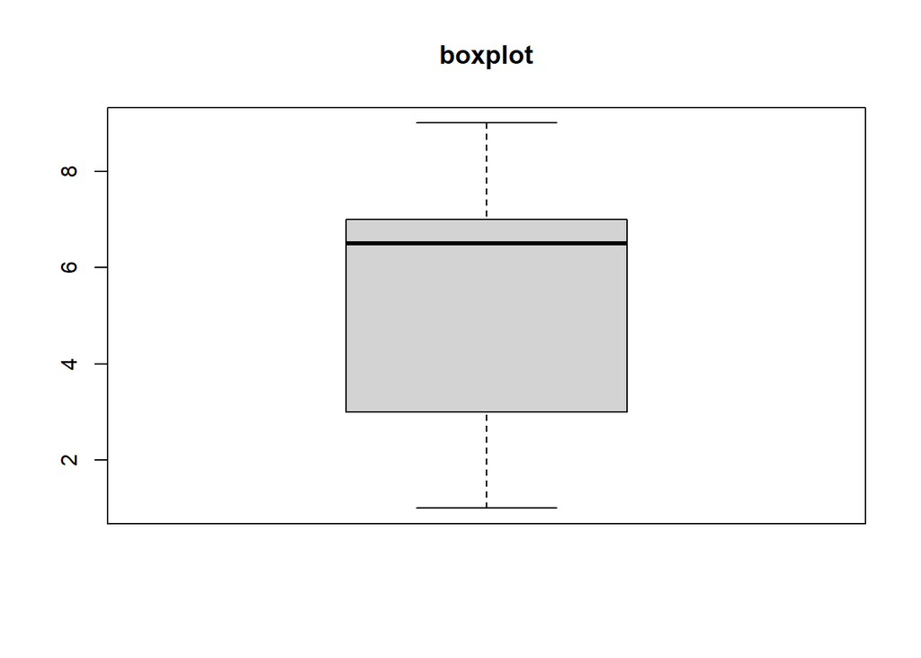

```r
boxplot(y)
title(main = "boxplot",x_lab = "xlab",y_lab = "ylab")
```

16.(D)以下R指令執行後的最後結果為何?

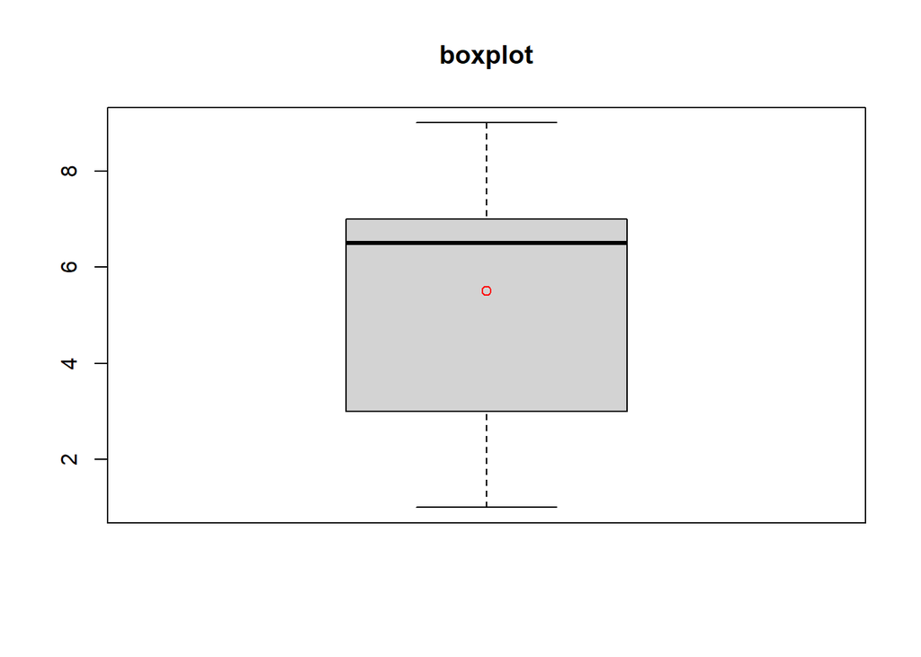

```r
boxplot(y)
title(main = "boxplot",x_lab = "xlab",y_lab = "ylab")
points(mean(y),col="red")
```

17.(A)欲將箱型圖圖檔輸出成pdf格式的R指令為何?  
(A)pdf(“e:/aaa.pdf”)  
boxplot(x)  
dev.off( )  
(B)boxplot(x)  
pdf(“e:/aaa.pdf”)  
dev.off( )  
(C)plot(x)  
pdf(“e:/aaa.pdf”)  
dev.off()  
(D)box(x)  
pdf(“e:/aaa.pdf”)  
dev.off( )

18.(D)以下圖型R指令可能為?  
(A)

```r
plot(x)
```

```r
#texts(2,5,"test text")
```

```r
plot(x)
```

```r
#point(2,5,"test text")
```

```r
#text(2,5,"test text")
plot(x)
```

(D)

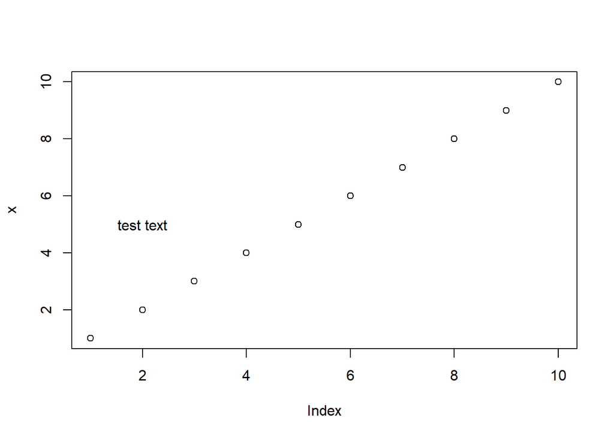

```r
plot(x)
text(2,5,"test text")
```

19.(A)以下圖型R指令可能為?  
(A)

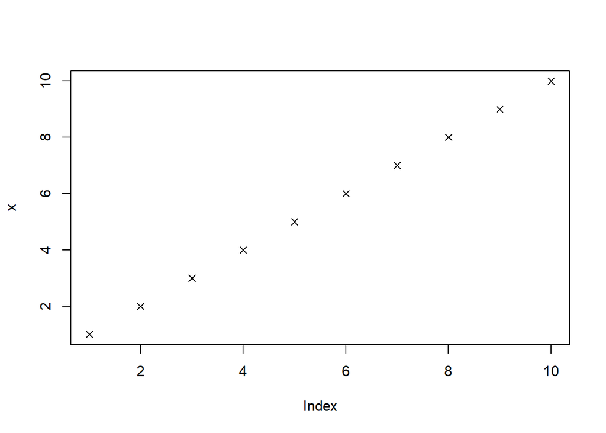

```r
plot(x,pch=4)
```

(B)

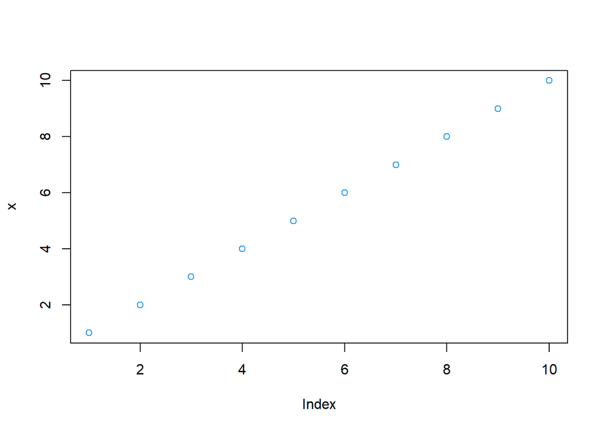

```r
plot(x,col=4)
```

(C)

```r
plot(x,cel=4)
```

(D)

```r
#plot(x,lab=4)
```

20.(C)以下圖型R指令可能為?  
(A)

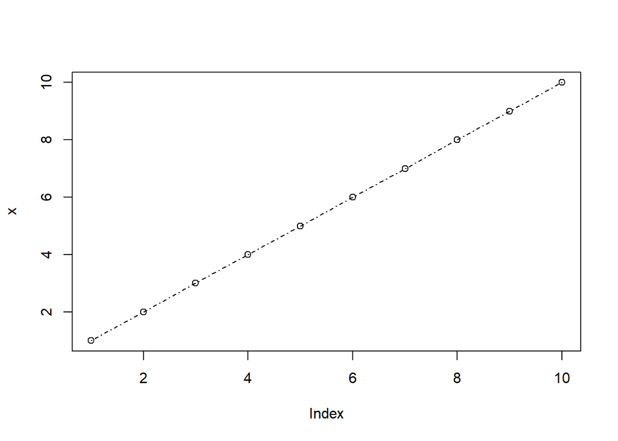

```r
plot(x)
lines(x,lty=10)
```

(B)

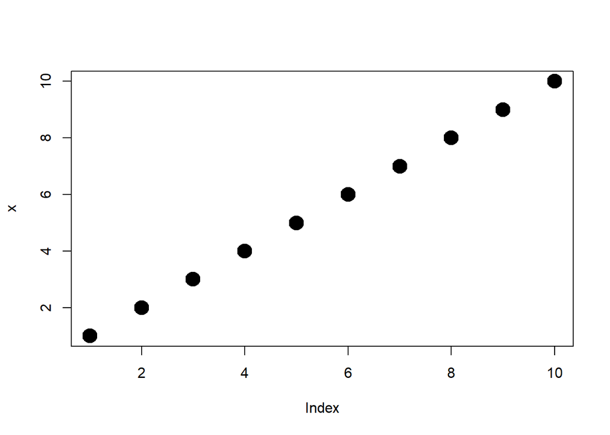

```r
plot(x)
points(x,lwd=10)
```

(C)

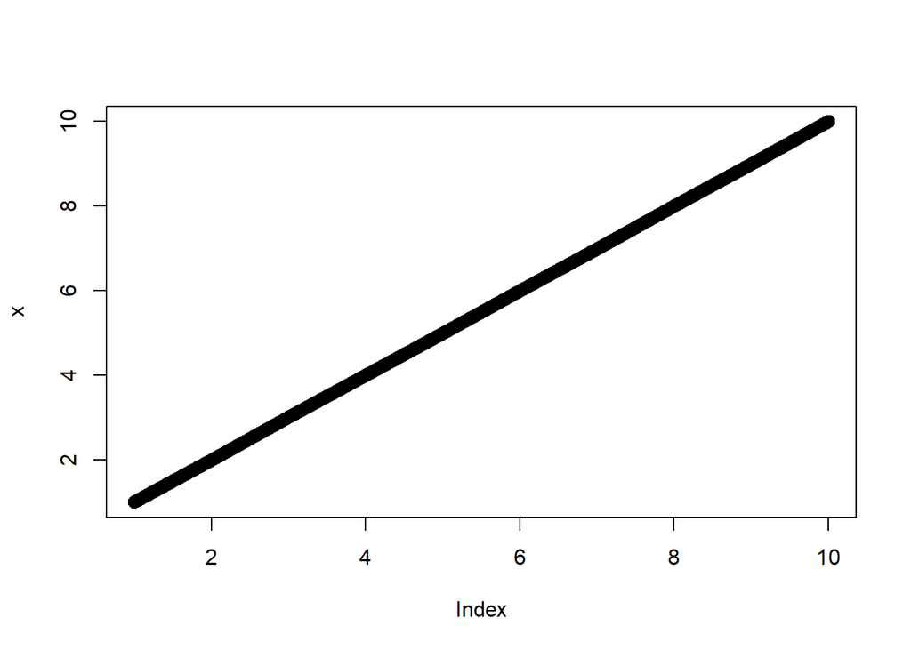

```r
plot(x)
lines(x,lwd=10)
```

(D)

```r
plot(x)
```

21.(A)以下R指令結果為?

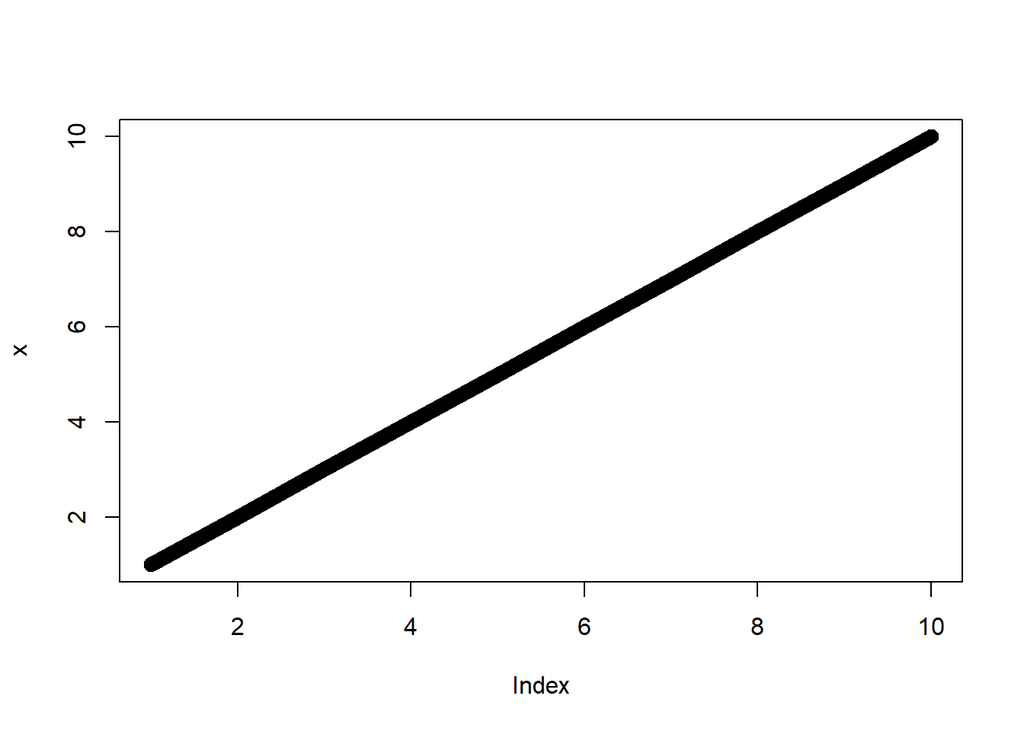

```r
x <- 1:10
plot(x)
lines(x,lwd=10)
```

1.(ABC)以下哪些函數是R繪製3D圖形函數?  
(A)persp() (B)contour() (C)image() (D)hist() (E)curve()  
2.(ABC)以下abline()低階繪圖函數哪些參數設定是正確的?  
(A)coef=c(1, 2) (B)a=3, b=2  
(C)h=4 (D)slope=3, intercept=2 (E)s=2, i=3  
3.(ABC)以下哪些是屬於低階繪圖函數?  
(A)abline() (B)legend() (C)axis() (D)curve() (E)persp( )  
4.(ACD)以下哪些是屬於高階繪圖函數?  
(A)barplot() (B)legend() (C)coplot() (D)curve() (E)persp()  
5.(ABC)以下哪些是屬於低階繪圖函數?  
(A)segment() (B)title() (C)points() (D)image() (E)contour()  
6.(ACD)以下R指令何者有錯?  
(A)

```r
#text(2, 5, "test text")
plot(x)
```

(B)

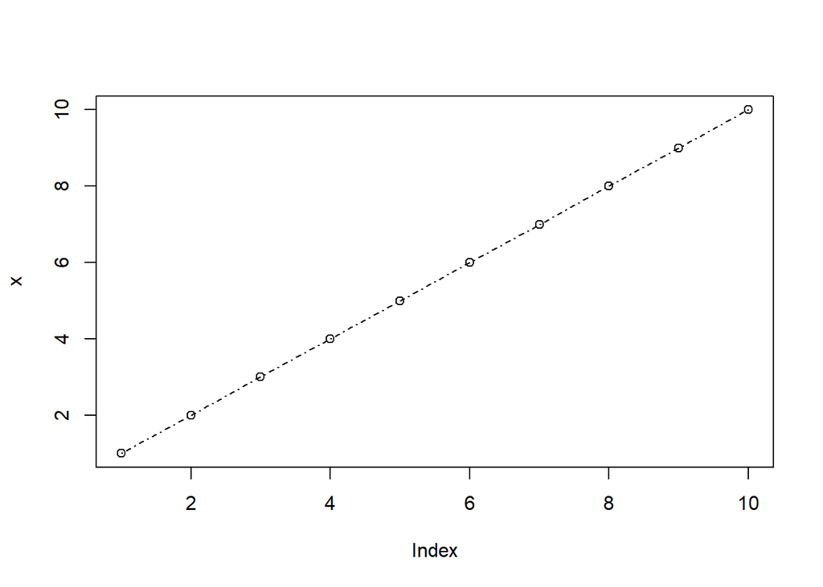

```r
plot(x)
lines(x, lty = 10)
```

(C)

```r
plot(x)
```

```r
#texts(2, 5, "test text")
```

```r
plot(x)
```

```r
#line(2,5,"test text")
```

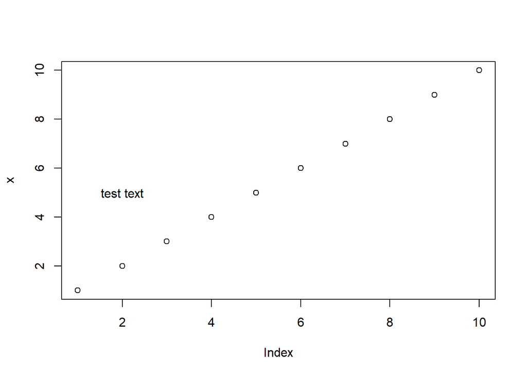

```r
plot(x)
text(2, 5,"test text")
```

7.(ADE)以下R指令何者有錯?  
(A)doc(“e:/aaa.doc”)  
boxplot(x)  
dev.off( )  
(B)bmp(“e:/aaa.bmp”)  
boxplot(x)  
dev.off( )  
(C)pdf(“e:/aaa.pdf”)  
boxplot(x)  
dev.off( )  
(D)box(x)  
(E)bmp(“e:/aaa.bmp”)  
boxplots(x)  
dev.off( )

```r
plot(x, pch = 2)
```

(B)

```r
plot(x, type = "n")
points(x, pch = 2)
```

(C)

```r
plot(x, type = "n")
points(x, pch = 2)
```

(D)

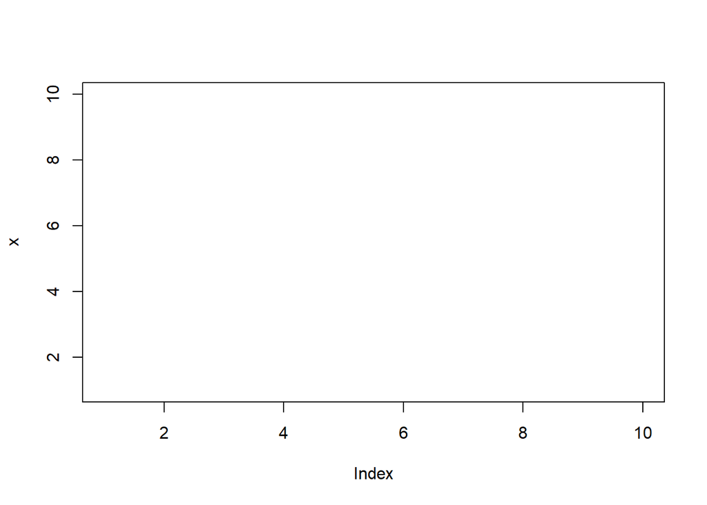

```r
plot(x,type="n")
```

```r
#point(x, pch=2)
```

```r
#plot(x, type = 2)
```